# prophetのpredict()

UPDATE: 2021-09-15 00:09:29

# 1 はじめに

ここでは、下記のドキュメントを参考に、`prophet`パッケージの基本的な使い方をおさらいすることを目的としています。ゆくゆくは外部予測変数を追加したモデルやクロスバリデーション、パラメタチューニングなどなど、モデルを発展させながら使用方法をまとめていきます。

- [Prophet | Forecasting at scale](https://facebook.github.io/prophet/docs/quick_start.html#r-api)

モデルの数理部分は下記の`prophet`に関する論文やブログ記事を参照願います。非常にわかりやすいです。

- [Forecasting at scale](https://peerj.com/preprints/3190/)
- [Prophet入門【理論編】Facebookの時系列予測ツール](https://www.slideshare.net/hoxo_m/prophetfacebook)
- [Prophetのモデル式を1から理解する](https://devblog.thebase.in/entry/2019/12/20/110000_1)
- [fb Prophetの解剖で学ぶベイズ時系列モデリング](https://ill-identified.hatenablog.com/entry/2018/05/28/020224)

# 2 ライブラリと関数の読み込み

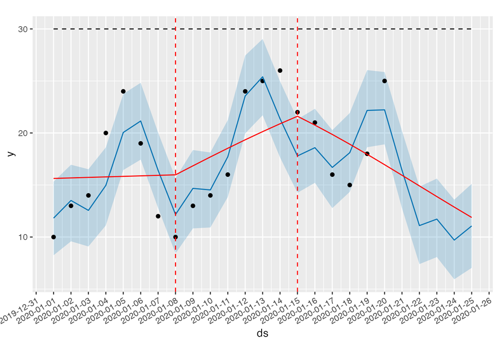

```r
library(prophet)
library(tidyverse)

time_diff <- function(ds1, ds2, units = "days") {
  return(as.numeric(difftime(ds1, ds2, units = units)))
}

d <- tibble::tibble(
  ds = seq(as.Date("2020-01-01"), as.Date("2020-01-20"), by = "day"),
  y = c(10,13,14,20,24,19,12,10,13,14,16,24,25,26,22,21,16,15,18,25),
  cap = 30
)

# このあとの説明で使用するのでモデルを学習させておきます。
set.seed(1989)
m <- prophet(df = d, growth = "logistic", changepoint.prior.scale = 2)
future_df <- prophet::make_future_dataframe(m, periods = 5) %>%
  dplyr::mutate(cap = 30)
forecast_df <- predict(m, future_df)
plot(m, forecast_df) + add_changepoints_to_plot(m) +
  scale_x_datetime(date_breaks = '1 day', labels = scales::date_format("%Y-%m-%d")) +
  theme(axis.text.x = element_text(angle = 30, hjust = 1))
```

# 3 prophetのpredict関数

ここまでのおさらいで、周期性や祝日効果、外部予測変数を除いて、Prophetがトレンドをどのように計算し、どのように変化点を見つけ、未来の予測において、どのように振る舞うのか、概要が把握できました。

ここでは`predict()`を実行した際に、どのような計算が行われていくのか、ソースコードをたどっていき、より理解を深めます。ここでは、季節周期や祝日効果、外部予測変数の部分は触れません。また、ロジスティクトレンドの場合をここでは扱うことにします。

Prophetのソースコードは下記より参照できます。

- [prophet/R/R/prophet.R](https://github.com/facebook/prophet/blob/a794018d654402ab6a97cb262e80d347db3485bd/R/R/prophet.R#L1303)

まずは`predict()`が予測値を返すまでの流れをおさえていきます。

`prophet`クラスの`predict()`は、学習したモデルと未来の日付が入ったデータフレームを受け取ると、`setup_dataframe()`でモデルに格納されている情報を使って、これ以降で必要な計算のための情報をデータフレームに付与していきます。

そして、`predict_trend()`が呼ばれ、この関数の中で、`piecewise_logistic()`が更に呼び出され、トレンドの計算が行われます。

その後に、`predict_uncertainty()`が呼び出され、未来のトレンドの計算の話に移ります。この関数の中では、`sample_posterior_predictive()`が呼び出され、MCMCまたはMAP推定でパラメタをシュミレーションするために、`sample_model()`が呼び出されます。この関数の中で、`sample_predictive_trend()`が呼び出され、未来の変化点の計算が行われ、未来のトレンドが返されます。

ここまで計算が進むと、少しデータフレームの情報を整えて、計算した値を元に予測値が計算されます。

```
#' @export
predict.prophet <- function(object, df = NULL, ...) {
  if (is.null(object$history)) {
    stop("Model must be fit before predictions can be made.")
  }
  if (is.null(df)) {
    df <- object$history
  } else {
    if (nrow(df) == 0) {
      stop("Dataframe has no rows.")
    }
    out <- setup_dataframe(object, df)
    df <- out$df
  }

  df$trend <- predict_trend(object, df)
  seasonal.components <- predict_seasonal_components(object, df)
  if (object$uncertainty.samples) {
    intervals <- predict_uncertainty(object, df)
  } else {
    intervals <- NULL
    }

  # Drop columns except ds, cap, floor, and trend
  cols <- c('ds', 'trend')
  if ('cap' %in% colnames(df)) {
    cols <- c(cols, 'cap')
  }
  if (object$logistic.floor) {
    cols <- c(cols, 'floor')
  }
  df <- df[cols]
  df <- dplyr::bind_cols(df, seasonal.components, intervals)
  df$yhat <- df$trend * (1 + df$multiplicative_terms) + df$additive_terms
  return(df)
}
```

ここでは主にトレンドの計算の部分、将来の変化点を計算する部分の実装見ていくことにします。

# 4 piecewise_logistic関数

この関数でロジスティクトレンドの計算を行っています。下記の数式に対応する部分です。

$$g(t) = \frac{C_{t}}{ 1 + exp(-(k + \boldsymbol{a}(t) \cdot \boldsymbol{\delta^{ \mathrm{T}}}) (t - (m + \boldsymbol{a}(t) \cdot \boldsymbol{\gamma^{ \mathrm{T}}}))}$$
$$\gamma_{j} = \left(s_{j} - m - \displaystyle \sum_{l \lt j} \gamma_{l}\right) \cdot
\left(1 - \frac{ k + \displaystyle \sum_{l \lt j} \delta_{l} }{k + \displaystyle \sum_{l \le j} \delta_{l}} \right)$$

```r
#' @keywords internal
piecewise_logistic <- function(t, cap, deltas, k, m, changepoint.ts) {
  # Compute offset changes
  k.cum <- c(k, cumsum(deltas) + k)
  gammas <- rep(0, length(changepoint.ts))
  for (i in 1:length(changepoint.ts)) {
    gammas[i] <- ((changepoint.ts[i] - m - sum(gammas))
                  * (1 - k.cum[i] / k.cum[i + 1]))
  }
  # Get cumulative rate and offset at each t
  k_t <- rep(k, length(t))
  m_t <- rep(m, length(t))
  for (s in 1:length(changepoint.ts)) {
    indx <- t >= changepoint.ts[s]
    k_t[indx] <- k_t[indx] + deltas[s]
    m_t[indx] <- m_t[indx] + gammas[s]

 # 著書が追加したブロック。下記のようにすれば、値の変化が確認できる。
 # -------------------------------------
 # dd <- data.frame(t = 1:20, indx, k_t = round(k_t,10)) %>% print(dd)
 #-------------------------------------

  }
  y <- cap / (1 + exp(-k_t * (t - m_t)))
  return(y)
}

# 下記の設定でpiecewise_logistic()を実行できる
t <- time_diff(d$ds, m$start, "secs") / m$t.scale
cap <- 30
k <- mean(m$params$k, na.rm = TRUE)
deltas <- colMeans(m$params$delta, na.rm = TRUE)
param.m <- mean(m$params$m, na.rm = TRUE)
changepoint.ts <- m$changepoints.t
piecewise_logistic(t, cap, deltas, k, param.m, changepoint.ts)
```

```
##  [1] 15.63167 15.68140 15.73111 15.78079 15.83026 15.87972 15.92916 15.97867
##  [9] 16.84364 17.69652 18.53175 19.34442 20.13017 20.88529 21.60665 20.75587
## [17] 19.85922 18.92201 17.95074 16.95303
```

モデルに格納されている`delta`の値を使えば、下記のProphetのドキュメントにあるような変化率のグラフを作成することもできます。

- [Trend Changepoint](https://facebook.github.io/prophet/docs/trend_changepoints.html)

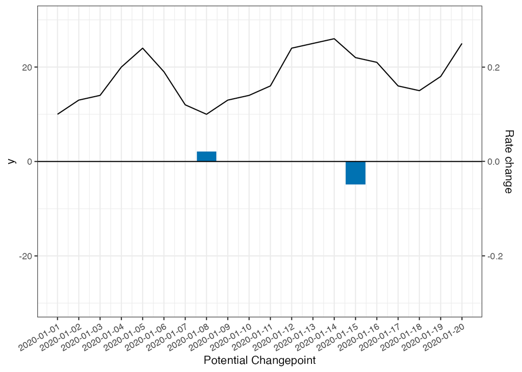

```r
df_delta <- tibble::tibble(
  changepoints= m$changepoints,
  changepoints_t = m$changepoints.t,
  delta = colMeans(m$params$delta),
  cumsum_delta = cumsum(colMeans(m$params$delta))
)

d %>%
  dplyr::left_join(df_delta, by = c("ds" = "changepoints")) %>%
  ggplot() +
  geom_bar(aes(ds, delta), stat = "identity", fill = "#0072B2") +
  geom_line(aes(ds, y)) +
  geom_hline(yintercept = 0) +
  scale_y_continuous(
    name = "y",
    limits = c(-30, 30),
    sec.axis = sec_axis(~ . * (1/100), name = "Rate change")
  ) +
  scale_x_datetime(date_breaks = '1 day', labels = scales::date_format("%Y-%m-%d")) +
  xlab("Potential Changepoint") +
  theme_bw() +
  theme(axis.text.x = element_text(angle = 30, hjust = 1))
```